# Application 4

Author

Martin Hsu

# Chutes and Ladders and MCMC

**This investigation concerns the boardgame Chutes and Ladders. Detailed instructions and some code has been provided; please be sure to read carefully.**

**The board has 100 spaces, labeled 1, 2, …, 100. A player starts off the board. A player generally moves on the board according to the roll of a fair six-sided die. For example, if the player is currently on space 13 and they roll a 5, then they move to space 18. However, the board also has 9 ladders which help the player climb the board.**

1. **Ladder from space 1 to space 38 (that is, landing on space 1 immediately moves the player to space 38, a gain of +37 spaces)**
2. **From 4 to 14 (+10)**
3. **From 9 to 31 (+22)**
4. **From 21 to 42 (+21)**
5. **From 28 to 84 (+56)**
6. **From 36 to 44 (+8)**
7. **From 51 to 67 (+16)**
8. **From 71 to 91 (+20)**
9. **From 80 to 100 (+20)**

**There are also 10 chutes (slides) which knock the player back down.**

1. **Chute from 16 to 6 (that is, landing on space 16 immediately moves the player to space 6, a loss of -10 spaces)**
2. **From 48 to 26 (-22)**
3. **From 49 to 11 (-38)**
4. **From 56 to 53 (-3)**
5. **From 62 to 19 (-43)**
6. **From 64 to 60 (-4)**
7. **From 87 to 24 (-63)**
8. **From 93 to 73 (-20)**
9. **From 95 to 75 (-20)**
10. **From 98 to 78 (-20)**

**The game ends when the player makes it to space 100. (We’ll assume only one player.)** *We are interested in $T$, the number of moves (rolls) needed until spot 100 is reached (the player doesn’t need to land on 100 exactly).* **The position of the player after the nth move can be modeled as a Markov chain with transition matrix `Pgame` defined in the code below.**

**The following assumptions should be apparent from the transition matrix, but to be clear:**

- **If the player rolls and lands on a chute/ladder, this counts as one move, not two.**
- **The player does not have to land on 100 exactly. For example, from spot 97, a roll or 3 or higher will win.**

## Setup

### Packages

```r
library(tidyverse)
library(expm)
```

### Set Seed

```r
set.seed(545)
```

### Prewritten Functions

```r
mean_time_to_absorption <- function(transition_matrix, state_names = NULL) {

  absorbing_states = which(diag(transition_matrix) == 1)

  if (length(absorbing_states) == 0) stop("There are no absorbing states.")

  n_states = nrow(transition_matrix)

  transient_states = setdiff(1:n_states, absorbing_states)

  Q = transition_matrix[transient_states, transient_states]

  mtta = solve(diag(nrow(Q)) - Q, rep(1, nrow(Q)))

  if (is.null(state_names)) state_names = 1:n_states

  data.frame(start_state = state_names[transient_states],
             mean_time_to_absorption = mtta)
}
```

```r
pmf_of_time_to_absorption <- function(transition_matrix, state_names = NULL, start_state) {

  absorbing_states = which(diag(transition_matrix) == 1)

  if (length(absorbing_states) == 0) stop("There are no absorbing states.")

  n_states = nrow(transition_matrix)

  transient_states = setdiff(1:n_states, absorbing_states)

  if (is.null(state_names)) state_names = 1:n_states

  if (which(state_names == start_state) %in% absorbing_states) stop("Initial state is an absorbing state; absorption at time 0.")

  n = 1

  TTA_cdf = sum(transition_matrix[which(state_names == start_state), absorbing_states])

  while (max(TTA_cdf) < 0.999999) {

    n = n + 1

    TTA_cdf = c(TTA_cdf, sum((transition_matrix %^% n)[which(state_names == start_state), absorbing_states]))
  }

  TTA_pmf = TTA_cdf - c(0, TTA_cdf[-length(TTA_cdf)])

  data.frame(n = 1:length(TTA_pmf),
             prob_absorb_at_time_n = TTA_pmf)
}
```

### Setup Transition Matrix

```r
N = 100 # number of spaces on board

s = N + 1  # number of states

k = 6  # number of sides on die

# P0 is the transition matrix if there were no chutes/ladders
P0 = matrix(rep(0, s * s), nrow = s)

for (i in 1:(N - 1)){
  for (j in min(i + 1, N):min(i + k, N)){
    if (j == N){
      P0[i, j] = (i - N + k + 1) / k
      # don't need to land on 100 exactly
    } else {
      P0[i, j] = 1 / k
    }
  }
}

P0[N, N] = 1  # absorbing state

P0[s, 1:k] = 1 / k  # initial state
```

```r
# The make_board function takes as an input the starting spaces
# for chutes and ladders and outputs the transition matrix
# add the chutes/ladders by swapping appropriate columns
# with an annoying little detail for the two short chutes
# e.g. you can get from 50 to 53 by rolling a 3
# or by rolling a 6 and then sliding down the chute from 56 to 53

make_board <- function(ladder_start, chute_start, plot = FALSE){
  ladder_length = c(8, 10, 16, 20, 20, 21, 22, 37, 56)
  ladder_end = ladder_start + ladder_length
  chute_length = c(3, 4, 10, 20, 20, 20, 22, 38, 43, 63)
  chute_end = chute_start - chute_length
  P = P0
  for (j in 1:length(ladder_start)){
    i = which(P[, ladder_start[j]] > 0)
    P[i, ladder_end[j]] = P[i, ladder_start[j]]
    P[i, ladder_start[j]] = 0
    P[ladder_start[j], ] = rep(0, s)
    P[ladder_start[j], ladder_end[j]]=1
  }
  for (j in 1:length(chute_start)){
    i = which(P[, chute_start[j]] > 0)
    i1 = i[which(i <= chute_end[j])]
    P[i1, chute_end[j]] = P[i1, chute_start[j]] +
      P0[i1, chute_end[j]]
    P[i1, chute_start[j]] = 0
    i2 = i[which(i > chute_end[j])]
    P[i2, chute_end[j]] = P[i2, chute_start[j]]
    P[i2, chute_start[j]] = 0
    P[chute_start[j], ] = rep(0, s)
    P[chute_start[j], chute_end[j]] = 1
  }
  if (plot == TRUE){
    image(1:s, 1:s, t(P[c(s, 1:(s - 1)), c(s, 1:(s - 1))]),
          xlab = "", ylab = "",
          zlim = c(1 / k, 1), xaxt = "n", yaxt = "n",
          col = rainbow(k))
    axis(1, at = 1:s, labels = 0:(s - 1), cex.axis=0.4)
    axis(2, at = 1:s, labels = 0:(s - 1), cex.axis=0.4)
    grid(s, s)
  }
  return(P)
}
```

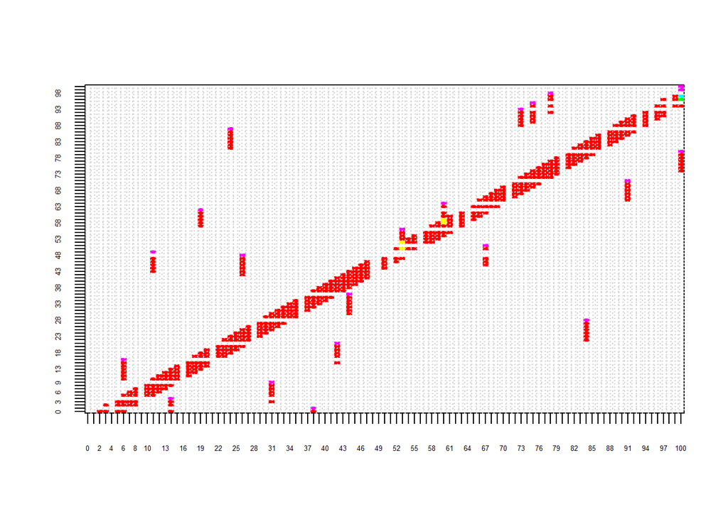

```r
# generate the transition matrix for the actual game
Pgame = make_board(
  ladder_start = c(36, 4, 51, 71, 80, 21, 9, 1, 28),
  chute_start = c(56, 64, 16, 93, 95, 98, 48, 49, 62, 87),
  plot = TRUE)
```

```r
# Check that all row sums are 1
which(!rowSums(Pgame) == 1)
```

```
integer(0)
```

## Problem 1

**First run the code above to create the Pgame matrix to use.**

### a)

**Solve for $E(T)$ without first finding the distribution of $T$.**

We can interpret this as a mean time to absorption (MTTA) problem. we want to find the MTTA for a starting state of 101, since that is where the players start.

```r
mtta <- mean_time_to_absorption(Pgame) %>%
  filter(start_state == 101)
mtta
```

| start_state | mean_time_to_absorption |
| --- | --- |
| 101 | 36.19307 |

Therefore, $E[T]$ = 36.1930702.

### b)

**Solve for the exact distribution of $T$ and plot it. (Technically, $T$ can take infinitely many values, but feel free to cut off when the probabilities become sufficiently small.) Find $E(T)$ based on this distribution. Compare the expected value to the previous part.**

We can plot the distribution of $T$ as follows:

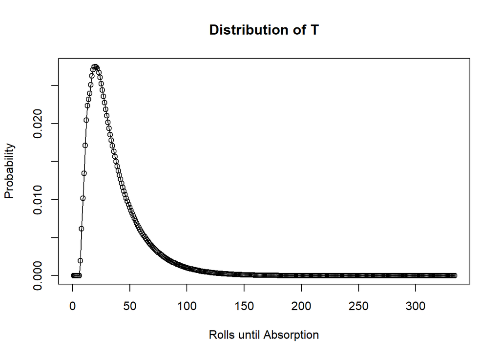

```r
dist <- pmf_of_time_to_absorption(Pgame, start_state = 101)
plot(dist$n, dist$prob_absorb_at_time_n, type="l",
     xlab="Rolls until Absorption", ylab="Probability",
     main="Distribution of T")
points(dist$n, dist$prob_absorb_at_time_n)
```

### c)

**Write code to simulate run the chain and simulate the distribution of $T$. Plot the simulated distribution, use it to estimate the expected value, and compare to the previous part.**

We can write a function to generate a single MCMC according to the problem specifications. We want it to simulate a traversal of the Chutes and Ladders board, until the “player” wins by reaching 100.

```r
sim_game <- function(P, start_state) {
  mhc <- numeric()
  i <- 1
  mhc[[i]] <- start_state
  while (mhc[[i]] != 100) {
    i <- i + 1
    mhc[[i]] <- sample(1:101, 1, prob=P[mhc[[i-1]],])
  }

  return(mhc)
}
```

Below is an example of a path ending with the player winning.

```r
game <- sim_game(Pgame, 101)
cat(game)
```

```
101 3 5 8 11 14 20 26 32 38 41 47 26 30 33 35 39 40 42 46 26 32 37 43 44 46 11 15 42 43 46 67 68 70 72 78 100
```

We can generate many simulated playthroughs of the game and store the number of rolls it takes for the player to reach 100 in each simulation.

```r
reps <- 100000
T_sim <- numeric(reps)
for (i in 1:reps) {
  T_sim[[i]] <- length(sim_game(Pgame, 101))
}
cat(head(T_sim))
```

```
55 33 46 30 102 54
```

Below, we plot the distribution of the simulated values with the target distribution overlaid in red.

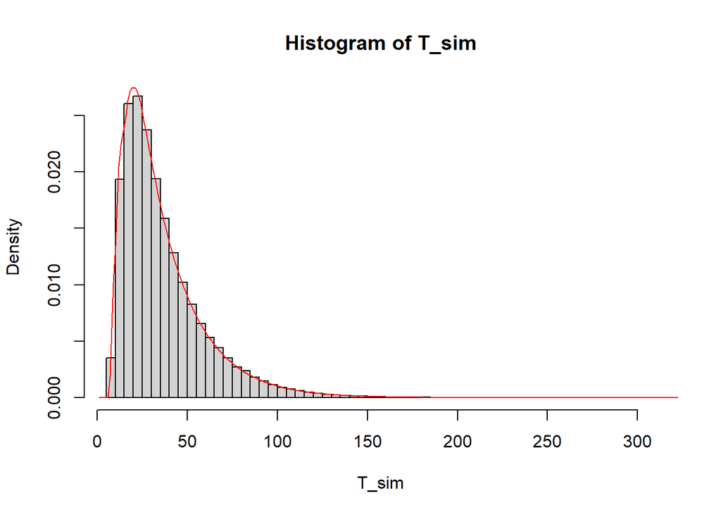

```r
hist(T_sim, breaks=50, probability=TRUE)
lines(dist$n, dist$prob_absorb_at_time_n, col="red")
```

The distribution of values of $T$ generated from many simulated playthroughs as Markov chains closely matches the target distribution. We can also compare the simulated mean with the mean of the target distribution.

```r
c("simulated mean" = mean(T_sim), "actual mean" = mtta[1,2]) %>%
  t() %>%
  as.data.frame()
```

| simulated mean | actual mean |
| --- | --- |
| 37.16524 | 36.19307 |

The two values are relatively close.

## Problem 2

**Suppose you were designing a new Chutes and Ladders board. How does the placement of the chutes and ladders on the board affect the expected value of $T$? In particular, is there a way to place the chutes/ladders to minimize the expected number of moves? In this problem, you’ll write an MCMC algorithm to find the board which minimizes $E(T)$.**

**Assume the number of chutes does not change and the length of each chute does not change; similarly for ladders. What you can change is which square starts the chute/ladder. For example, there is currently a ladder from 4 to 14; you could change this into a ladder from 50 to 60. To be clear, your board should have**

1. **9 ladders with lengths 8, 10, 16, 20, 20, 21, 22, 37, 56**
2. **10 chutes with length 3, 4, 10, 20, 20, 20, 22, 38, 43, 63**

**Some rules to follow:**

- **You can only define chutes/ladders that start and end on the board.**
- **I haven’t included any error checks in the function, so** *it will be up to you to make sure you enter valid starting spaces* **(i.e, that your chutes/ladders don’t go off the board).**
- **You should not design a board with a chute that ends at the start of another chute or a ladder that ends at the start of another ladder. This would give you a way of effectively lengthening ladders or chutes, which voliates the spirit of this exercise.**
- **Similarly, you should not have chutes that end at the start of ladders and vice versa (as a way of creating shorter chutes).**
- **I would appreciate it if you wouldn’t have multiple ladders than end on the same space, or multiple chutes that end on the same space, unless you want to revise the make_board code to accommodate this. While technically this would be allowed, it is annoying to code. It’s a good idea to check that the row sums of any transition matrix are 1. If you do see sums that are less than 1, it’s probably because multiple ladders (or chutes) are ending in the same spot.**

**What to do. First, think about what the optimal placement might look like. Then, write an MCMC algorithm to find the board that minimizes $E(T)$. Your MCMC algorithm should involve:**

- **Proposing a new state, that is, proposing a new board. A board is identified by the starting spaces of the chutes and the starting spaces of the ladders (that is, the inputs to the make_board function).**
- **Finding the expected value of $T$ for the proposed board and then deciding whether or not to accept the proposed board. Note: if the proposed board is not valid (e.g., chutes/ladders land off the board), then it should be rejected.**

**Run the algorithm until you think it has converged and you have found the optimal board. Identify the the starting spaces for the chutes and ladders for this board. Then repeat Problem 1 for your optimal board, and compare the distribution of $T$ for your board to the one from the actual game. Write a few sentences summarizing your results.**

Below is an edited function of make board that takes into account the restrictions defined above.

```r
make_board_2 <- function(ladder_start, chute_start, plot = FALSE){
  ladder_length = c(8, 10, 16, 20, 20, 21, 22, 37, 56)
  ladder_end = ladder_start + ladder_length
  chute_length = c(3, 4, 10, 20, 20, 20, 22, 38, 43, 63)
  chute_end = chute_start - chute_length

  # If any rules violated, create an invalid matrix
  if(any(ladder_start %in% ladder_end) || # ladder can't start at ladder end
     any(chute_start %in% chute_end) || # chute can't start at chute end
     any(ladder_start %in% chute_end) || # ladder can't start at chute end
     any(chute_start %in% ladder_end) || # chute can't start at ladder end
     any(chute_start %in% ladder_start) || # chute can't start on same space as ladder (and vv)
     any(chute_end %in% ladder_end) || # chute can't end on same space as ladder (and vv)
     any(ladder_start < 1) || any(ladder_start > 100) || # ladder must start on valid board space
     any(chute_start < 1) || any(chute_start > 100) || # chute must start on valid board space
     any(ladder_end < 1) || any(ladder_end > 100) || # ladder must end on valid board space
     any(chute_end < 1) || any(ladder_end > 100) || # chute must end on valid board space
     any(table(ladder_end) > 1) || # ladders can't end on same space
     any(table(chute_end) > 1) || # chutes can't end on same space
     any(table(ladder_start) > 1) || # ladders can't start on same space
     any(table(chute_start) > 1) # chutes can't start on same space
     ) {
    return(matrix(data=-1, nrow=101, ncol=101))
  }

  P = P0
  for (j in 1:length(ladder_start)){
    i = which(P[, ladder_start[j]] > 0)
    P[i, ladder_end[j]] = P[i, ladder_start[j]]
    P[i, ladder_start[j]] = 0
    P[ladder_start[j], ] = rep(0, s)
    P[ladder_start[j], ladder_end[j]]=1
  }
  for (j in 1:length(chute_start)){
    i = which(P[, chute_start[j]] > 0)
    i1 = i[which(i <= chute_end[j])]
    P[i1, chute_end[j]] = P[i1, chute_start[j]] +
      P0[i1, chute_end[j]]
    P[i1, chute_start[j]] = 0
    i2 = i[which(i > chute_end[j])]
    P[i2, chute_end[j]] = P[i2, chute_start[j]]
    P[i2, chute_start[j]] = 0
    P[chute_start[j], ] = rep(0, s)
    P[chute_start[j], chute_end[j]] = 1
  }
  if (plot == TRUE){
    image(1:s, 1:s, t(P[c(s, 1:(s - 1)), c(s, 1:(s - 1))]),
          xlab = "", ylab = "",
          zlim = c(1 / k, 1), xaxt = "n", yaxt = "n",
          col = rainbow(k))
    axis(1, at = 1:s, labels = 0:(s - 1), cex.axis=0.4)
    axis(2, at = 1:s, labels = 0:(s - 1), cex.axis=0.4)
    grid(s, s)
  }
  return(P)
}
```

We can then create a MCMC algorithm to simulate many boards and find the one with the smallest expected time to absorption, which is defined as the reaching state 100.

1. Start with given chute and ladder position. Calculate the MTTA $\mu_{101}$. This will be the best $E[T]$ for now.
2. Propose a new board setup by randomly shifting a chute or ladder forward or backwards one position.
3. Calculate the acceptance probability as $a=\min(1, \frac{\exp(\text{MTTA}_c}{\exp(\text{MTTA}_p)})$.
4. If the board violates the rules outline in the problem, we reject the new board setup. Otherwise, we accept the new board setup with probability $a$.
5. Calculate the MTTA $\mu_{101}$ for the new board. If it is smaller than the best $E[T]$, update the best $E[T]$ by replacing it with $\mu_{101}$.
6. Repeat steps 2 thru 5 until the simulation converges on a minimized $E[T]$.

We implement this in the code below:

```r
# Define number of reps
reps <- 100000

# Start chutes and ladder positions
ladder_c <- c(36, 4, 51, 71, 80, 21, 9, 1, 28)
chute_c <- c(56, 64, 16, 93, 95, 98, 48, 49, 62, 87)

# Starting board and E[T] aka MTTA
board_c <- make_board_2(ladder_c, chute_c)
mtta_c <- as.matrix(mean_time_to_absorption(board_c))
mtta_c <- mtta_c[mtta_c[,1]==101][2]

# Best ladder/chute positions and E[T] are the starting ones for now
board_best <- board_c
ladder_best <- ladder_c
chute_best <- chute_c
mtta_best <- mtta_c

# Perform algorithm
for (i in 1:reps) {
  # Select which object to shift in the board
  # Select chute or ladder by relative frequency
  change <- sample(c("chute", "ladder"), 1, prob=c(10, 9))
  # Shift one chute or ladder by 1 up or down
  if (change == "chute") {
    change_start <- sample(1:10, 1)
    chute_p <- chute_c
    ladder_p <- ladder_c
    chute_p[change_start] <- chute_p[change_start] + sample(c(-1, 1), 1)
  } else if (change == "ladder") {
    change_start <- sample(1:9, 1)
    ladder_p <- ladder_c
    chute_p <- chute_c
    ladder_p[change_start] <- ladder_p[change_start] + sample(c(-1, 1), 1)
  }

  # Make new board
  board_p <- make_board_2(ladder_p, chute_p)
  a <- 0

  # Calculate acceptance probability of new board given that it doesn't violate
  #   any rules
  if (!(any(board_p==-1))) {
    if(any(rowSums(board_p) != 1)) {
      print(board_p)
      stop("rowsum != 1")
    }
    mtta_p <- as.matrix(mean_time_to_absorption(board_p))
    mtta_p <- mtta_p[mtta_p[,1]==101][2]
    a <- min(1, exp(mtta_c) / exp(mtta_p))
  }

  # Accept or reject new board
  accept <- sample(c("p", "c"), 1, prob=c(a, 1-a))
  if (accept == "p") {
    board_c <- board_p
    chute_c <- chute_p
    ladder_c <- ladder_p
    mtta_c <- mtta_p
  }
  # Update best E[T]
  if (mtta_best > mtta_c) {
    board_best <- board_c
    mtta_best <- mtta_c
    chute_best <- chute_c
    ladder_best <- ladder_c
  }
}
```

Below we can find our results from the MCMC:

```r
cat("Minimum E[T]:", mtta_best)
```

```
Minimum E[T]: 30.3039
```

```r
cat("Chute Positions:", chute_best)
```

```
Chute Positions: 57 63 17 92 94 97 46 51 61 86
```

```r
cat("Ladder Positions:", ladder_best)
```

```
Ladder Positions: 36 6 53 70 80 22 8 5 29
```

We are able to minimize the $E[T]$ to 30.304 rolls using the MCMC. This is a large improvement given the previous board setup’s $E[T]$, 36.1930702

We can also compare the distribution of our board setup to the original board setup:

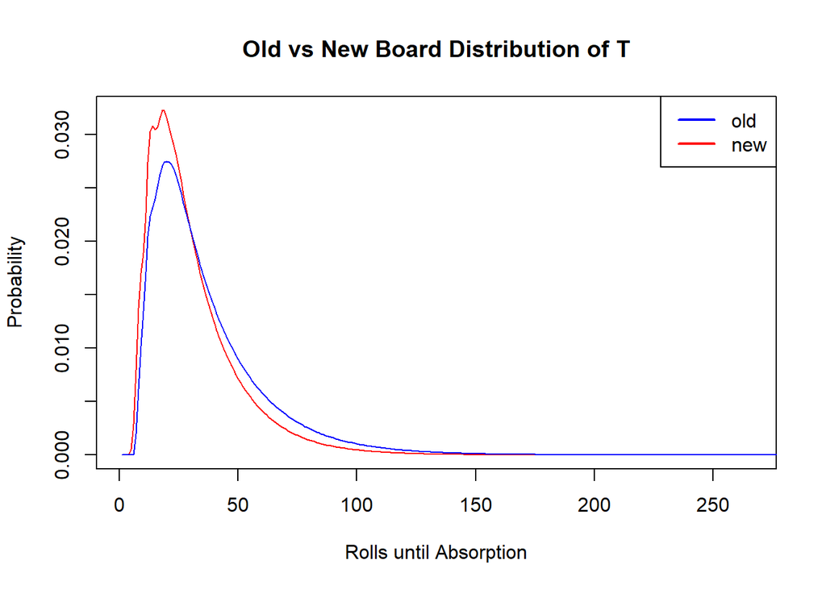

```r
dist_new <- pmf_of_time_to_absorption(board_best, start_state=101)
plot(dist_new$n, dist_new$prob_absorb_at_time_n, col="red", type="l",
     xlab="Rolls until Absorption", ylab="Probability",
     main="Old vs New Board Distribution of T")
lines(dist$n, dist$prob_absorb_at_time_n, col="blue")
legend("topright", legend=c("old", "new"), col=c("blue", "red"), lwd="2")
```

We can simulate playthroughs from our board and get a distribution of simulated $T$ values.

```r
reps <- 100000
T_new <- numeric(reps)
for (i in 1:reps) {
  T_new[[i]] <- length(sim_game(board_best, 101))
}
```

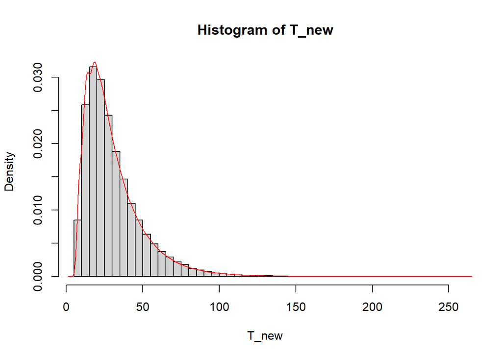

```r
hist(T_new, breaks=50, probability=TRUE)
lines(dist_new$n, dist_new$prob_absorb_at_time_n, col="red")
```

The distribution of values of $T$ generated from many simulated playthroughs as Markov chains closely matches the target distribution. We can also compare the simulated mean with the mean of the target distribution.

```r
c("simulated mean" = mean(T_new), "actual mean" = mtta_best) %>%
  t() %>%
  as.data.frame()
```

| simulated mean | actual mean |
| --- | --- |
| 31.37252 | 30.3039 |

The two values are relatively close.